# HW1: L2 Regularized Logistic Regression

From Scratch Implementation to Real-World Heart Disease Prediction

## Instructions

1. You may talk to a friend, discuss the questions and potential directions for solving them. However, you need to write your own solutions and code separately, and not as a group activity.
2. Write your code in the **Code cells** and your answers in the **Markdown cells** of the Jupyter notebook. Ensure that the solution is written neatly enough to for the graders to understand and follow.
3. Use [Quarto](https://quarto.org/docs/output-formats/html-basics.html) to render the **.ipynb** file as HTML. You will need to open the command prompt, navigate to the directory containing the file, and use the command: `quarto render filename.ipynb --to html`. Submit the HTML file.
4. The assignment is worth 100 points, and is due on **18th October 2025 at 11:59 pm**.
5. **Five points are properly formatting the assignment**. The breakdown is as follows:
   - Must be an HTML file rendered using Quarto **(1 point)**. *If you have a Quarto issue, you must mention the issue & quote the error you get when rendering using Quarto in the comments section of Canvas, and submit the ipynb file.*
   - No name can be written on the assignment, nor can there be any indicator of the student’s identity—e.g. printouts of the working directory should not be included in the final submission. **(1 point)**
   - There aren’t excessively long outputs of extraneous information (e.g. no printouts of entire data frames without good reason, there aren’t long printouts of which iteration a loop is on, there aren’t long sections of commented-out code, etc.) **(1 point)**
   - Final answers to each question are written in the Markdown cells. **(1 point)**
   - There is no piece of unnecessary / redundant code, and no unnecessary / redundant text. **(1 point)**
6. The maximum possible score in the assigment is 100 + 15 (bonus task) + 5 (AI usage disclosure)= 120 out of 100.

## 1 Objective

- **Reinforce Knowledge of Gradient Descent:** Apply your understanding of gradient descent to classification problems by implementing logistic regression and softmax regression from scratch.
- **Hands-on Implementation:** Build classification models manually to gain deeper insights into their mathematical foundations and working principles.
- **Explore Customization Options:** Learn how implementing models from scratch allows you to:
  - Adjust and optimize model parameters for specific requirements.
  - Add features or constraints that might not be possible with standard libraries.
- **Compare with Pre-built Models:** Use scikit-learn’s logistic regression as a baseline to evaluate the performance and efficiency of your custom implementation. This will help you understand when to use custom models and when to leverage pre-built ones.
- **Prepare for Real-world Scenarios:** Understand the scenarios where off-the-shelf models are not sufficient, allowing you to confidently tackle complex machine learning problems and create novel solutions.

```python
import numpy as np
import pandas as pd
import matplotlib.pyplot as plt
```

## 2 Refreshing the Foundations: Sigmoid & Logistic Regression

### 2.1 Why Logistic Regression? The Classification Challenge

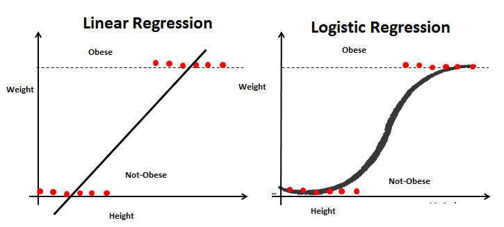

**The Problem**: Linear regression gives us $f_{\mathbf{w},b}(\mathbf{x}^{(i)}) = \mathbf{w} \cdot \mathbf{x}^{(i)} + b$, but for classification:

- **Linear regression outputs**: Any real number (-∞ to +∞)
- **Classification needs**: Probabilities between 0 and 1
- **Binary targets**: $y \in \{0, 1\}$ (e.g., Disease/No Disease, Spam/Not Spam)

**The Solution**: Transform linear outputs into probabilities using the **sigmoid function**, creating a model that outputs meaningful probabilities for binary classification decisions.

**Real-World Context**: In this assignment, you’ll predict heart disease risk where: - **Input**: Patient medical data (age, cholesterol, chest pain type, etc.) - **Output**: Probability of heart disease (0 = healthy, 1 = disease) - **Goal**: Build a model doctors can trust for medical decision-making

### 2.2 The Sigmoid Function: Mathematical Bridge to Probabilities

**Mathematical Definition:**
$$g(z) = \frac{1}{1 + e^{-z}} \tag{1}$$

**What This Function Does:** - **Input $z$**: Any real number (-∞ to +∞) from linear model - **Output $g(z)$**: Always between 0 and 1 (perfect for probabilities!) - **S-shaped curve**: Smooth transition from 0 to 1

**Key Properties:** - **$g(0) = 0.5$**: Neutral prediction (equal probability of both classes) - **$g(z) \to 1$** as $z \to +\infty$: Strong positive evidence → high probability  
- **$g(z) \to 0$** as $z \to -\infty$: Strong negative evidence → low probability - **Always smooth**: No sudden jumps, making it perfect for gradient descent optimization

**Practical Interpretation:** In logistic regression, $z = \mathbf{w} \cdot \mathbf{x} + b$ represents the “log-odds” or “logit”: - **Positive $z$**: Model leans toward class 1 (e.g., “has disease”) - **Negative $z$**: Model leans toward class 0 (e.g., “healthy”)  
- **Magnitude of $|z|$**: Confidence level of the prediction

**Implementation Note**: NumPy’s [`exp()`](https://numpy.org/doc/stable/reference/generated/numpy.exp.html) function handles vectorized computation efficiently, but requires careful numerical handling to avoid overflow (which you’ll implement!).

### 2.3 Logistic Regression: Model

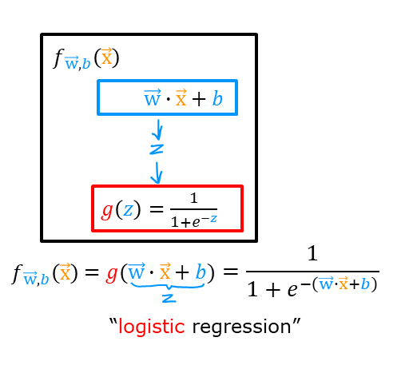

A logistic regression model applies the sigmoid to the familiar linear regression model as shown below:

$$f_{\mathbf{w},b}(\mathbf{x}^{(i)}) = g(\mathbf{w} \cdot \mathbf{x}^{(i)} + b ) \tag{2}$$

where

$$g(z) = \frac{1}{1+e^{-z}}\tag{3}$$

### 2.4 Logistic Regression: Loss Function

Logistic Regression uses a loss function more suited to the task of categorization where the target is 0 or 1 rather than any number.

> **Definition Note:** In this course, these definitions are used:  
> **Loss** is a measure of the difference of a single example to its target value while the  
> **Cost** is a measure of the losses over the training set

This is defined: * $loss(f_{\mathbf{w},b}(\mathbf{x}^{(i)}), y^{(i)})$ is the cost for a single data point, which is:

$$\begin{equation}
loss(f_{\mathbf{w},b}(\mathbf{x}^{(i)}), y^{(i)}) = \begin{cases}
- \log\left(f_{\mathbf{w},b}\left( \mathbf{x}^{(i)} \right) \right) & \text{if $y^{(i)}=1$}\\
- \log \left( 1 - f_{\mathbf{w},b}\left( \mathbf{x}^{(i)} \right) \right) & \text{if $y^{(i)}=0$}
\end{cases}
\end{equation}$$

- $f_{\mathbf{w},b}(\mathbf{x}^{(i)})$ is the model’s prediction, while $y^{(i)}$ is the target value.
- $f_{\mathbf{w},b}(\mathbf{x}^{(i)}) = g(\mathbf{w} \cdot\mathbf{x}^{(i)}+b)$ where function $g$ is the sigmoid function.

The defining feature of this loss function is the fact that it uses two separate curves. One for the case when the target is zero or ($y=0$) and another for when the target is one ($y=1$). Combined, these curves provide the behavior useful for a loss function, namely, being zero when the prediction matches the target and rapidly increasing in value as the prediction differs from the target. Consider the curves below:

[output not shown]

Combined, the curves are similar to the quadratic curve of the squared error loss. Note, the x-axis is $f_{\mathbf{w},b}$ which is the output of a sigmoid. The sigmoid output is strictly between 0 and 1.

The loss function above can be rewritten to be easier to implement.
$$loss(f_{\mathbf{w},b}(\mathbf{x}^{(i)}), y^{(i)}) = (-y^{(i)} \log\left(f_{\mathbf{w},b}\left( \mathbf{x}^{(i)} \right) \right) - \left( 1 - y^{(i)}\right) \log \left( 1 - f_{\mathbf{w},b}\left( \mathbf{x}^{(i)} \right) \right)$$

This is a rather formidable-looking equation. It is less daunting when you consider $y^{(i)}$ can have only two values, 0 and 1. One can then consider the equation in two pieces:
when $ y^{(i)} = 0$, the left-hand term is eliminated:$$
$$\begin{align}
loss(f_{\mathbf{w},b}(\mathbf{x}^{(i)}), 0) &= (-(0) \log\left(f_{\mathbf{w},b}\left( \mathbf{x}^{(i)} \right) \right) - \left( 1 - 0\right) \log \left( 1 - f_{\mathbf{w},b}\left( \mathbf{x}^{(i)} \right) \right) \\
&= -\log \left( 1 - f_{\mathbf{w},b}\left( \mathbf{x}^{(i)} \right) \right)
\end{align}$$
$$and when $ y^{(i)} = 1$, the right-hand term is eliminated:$$
$$\begin{align}
loss(f_{\mathbf{w},b}(\mathbf{x}^{(i)}), 1) &= (-(1) \log\left(f_{\mathbf{w},b}\left( \mathbf{x}^{(i)} \right) \right) - \left( 1 - 1\right) \log \left( 1 - f_{\mathbf{w},b}\left( \mathbf{x}^{(i)} \right) \right)\\
&= -\log\left(f_{\mathbf{w},b}\left( \mathbf{x}^{(i)} \right) \right)
\end{align}$$
$$

**Why This Loss Function Works:** 1. **Probabilistic Foundation**: Derived from maximum likelihood estimation 2. **Convex Optimization**: Guarantees unique global minimum (perfect for gradient descent) 3. **Penalizes Confidence**: Wrong confident predictions get heavily penalized 4. **Smooth Gradients**: Enables stable gradient descent convergence

**Connection to Your Implementation**: This loss function is exactly what you’ll implement in Task 1, with the addition of L2 regularization to prevent overfitting on the heart disease dataset.

### 2.5 Logistic Regression: Cost Function (Training Objective)

**From Individual Loss to Overall Cost:**

The **cost function** aggregates individual losses across all training examples to create our optimization objective:

$$J(\mathbf{w},b) = \frac{1}{m} \sum_{i=0}^{m-1} \left[ loss(f_{\mathbf{w},b}(\mathbf{x}^{(i)}), y^{(i)}) \right] \tag{1}$$

Where the individual **loss** for each example is:

$$loss(f_{\mathbf{w},b}(\mathbf{x}^{(i)}), y^{(i)}) = -y^{(i)} \log\left(f_{\mathbf{w},b}\left( \mathbf{x}^{(i)} \right) \right) - \left( 1 - y^{(i)}\right) \log \left( 1 - f_{\mathbf{w},b}\left( \mathbf{x}^{(i)} \right) \right) \tag{2}$$

**The Complete Model Pipeline:**
$$\begin{align}
f_{\mathbf{w},b}(\mathbf{x^{(i)}}) &= g(z^{(i)})\tag{3} \\
z^{(i)} &= \mathbf{w} \cdot \mathbf{x}^{(i)}+ b\tag{4} \\
g(z^{(i)}) &= \frac{1}{1+e^{-z^{(i)}}}\tag{5}
\end{align}$$

**Optimization Goal**: Find weights $\mathbf{w}$ and bias $b$ that minimize $J(\mathbf{w},b)$ using **gradient descent**.

## 3 Bridge to Implementation: What You’ll Build

### 3.1 Your Assignment Journey:

1. **Task 1**: Implement cost function with L2 regularization → **20 points**
2. **Task 2**: Apply to heart disease dataset with preprocessing → **15 points**
3. **Task 3**: Experiment with regularization strength (λ) → **20 points**
4. **Task 4**: Benchmark against scikit-learn LogisticRegression → **20 points**
5. **Task 5**: Explore the `tol` parameter in gradient descent–based models → **15 points**
6. **Task 6**: Summarize key learnings and insights → **5 points**

### 3.2 ⭐ Bonus Task

Extend your L2-regularized logistic regression by adding a **`tol` stopping criterion**, and compare its behavior with scikit-learn’s implementation -> **15 points**

### 3.3 Key Implementation Challenges You’ll Solve:

- **Numerical Stability**: Prevent `log(0)` errors that break gradient descent
- **Vectorization**: Implement efficient matrix operations for real-world performance
- **Regularization**: Add L2 penalty to prevent overfitting on complex medical data
- **Gradient Computation**: Derive and implement the gradient for weight updates
- **Convergence Monitoring**: Track training progress and detect overfitting

### 3.4 Real-World Impact:

Your implementation will predict heart disease risk using patient data—a model that could potentially assist medical professionals in making life-saving decisions. The mathematical rigor you develop here translates directly to production ML systems used in healthcare, finance, and technology.

## 4 Task 1: Implementing L2 Regularized Logistic Regression with Vectorized Gradient Descent **(20 points)**

### 4.1 **Objective**

Implement a complete L2 regularized (Ridge) logistic regression algorithm from scratch using vectorized operations to prevent overfitting in binary classification problems.

### 4.2 📋 **Implementation Requirements**

#### 4.2.1 **Main Function Signature**

Your implementation should create a main training function that takes these inputs:

- **X_train** (ndarray): Training feature matrix (m × n) - **Note**: Should include bias column of ones as first column
- **y_train** (ndarray): Training labels (m × 1)
- **X_test** (ndarray): Test feature matrix for monitoring overfitting - **Note**: Should include bias column
- **y_test** (ndarray): Test labels for performance tracking
- **w_in** (ndarray): Initial weights ((n+1) × 1) - **Includes bias weight as first element**
- **alpha** (float): Learning rate (typically 0.001 - 0.01)
- **num_iters** (int): Number of training iterations
- **lambda_reg** (float): L2 regularization strength (λ ≥ 0)

#### 4.2.2 **Expected Outputs**

- **Optimized parameters**: Final weights after training
- **Training cost history**: Cost values at each iteration on training data
- **Test cost history**: Cost values at each iteration on test data (for overfitting analysis)

### 4.3 **Implementation Structure**

#### 4.3.1 **Step 1: Cost Function with L2 Regularization**

```python
def compute_cost_logistic_ridge(X, y, w, lambda_reg):
```

**Mathematical Formula:**
$$J(w) = \frac{1}{m}\sum_{i=1}^{m} \left[ -y^{(i)} \log(h_w(x^{(i)})) - (1-y^{(i)}) \log(1-h_w(x^{(i)})) \right] + \frac{\lambda}{2m} \sum_{j=1}^{n} w_j^2$$

Where $h_w(x) = \sigma(w^T x)$ and $\sigma(z) = \frac{1}{1+e^{-z}}$

**Key Implementation Notes:**

- Use vectorized operations for efficiency
- **Bias handling**: Don’t regularize the bias term (w[0]) - exclude from L2 penalty
- **Data preparation**: Add column of ones to X matrices for bias term
- Handle numerical stability with log functions

**Why Numerical Stability Matters:**

- **When h = 0**: `log(0) = -∞` → **NaN in cost calculations**
- **When h = 1**: `log(1-h) = log(0) = -∞` → **NaN in cost calculations**
- **When it occurs**: Sigmoid outputs extreme values (overconfident predictions)
- **Consequence**: Entire gradient descent breaks due to NaN propagation

  **Practical Example:** ```python # Without clipping - BREAKS! h = np.array([0.0, 0.5, 1.0]) # Sigmoid predictions cost = -np.log(h) # Returns: [inf, 0.693, 0.0] # ↑ inf values propagate to gradients → NaN → training failure

  # With clipping - WORKS! h_safe = np.clip(h, 1e-15, 1-1e-15) # Safe range: [1e-15, 1-1e-15] cost = -np.log(h_safe) # Returns: [34.54, 0.693, 34.54]  
  # ↑ All finite values → stable gradients → successful training ```

**Professional Tip**: All major ML libraries (TensorFlow, PyTorch, sklearn) use similar clipping internally!

#### 4.3.2 **Step 2: Gradient Computation with L2 Regularization**

```python
def compute_gradient_logistic_ridge(X, y, w, lambda_reg):
```

**Mathematical Formula:**
$$\frac{\partial J}{\partial w_j} = \frac{1}{m} X^T (\sigma(Xw) - y) + \frac{\lambda}{m} w_j \quad \text{(for } j > 0\text{)}$$
$$\frac{\partial J}{\partial w_0} = \frac{1}{m} X^T (\sigma(Xw) - y) \quad \text{(bias term, no regularization)}$$

**Implementation Note**: The gradient vector should be same shape as w_in ((n+1) × 1), where the first element corresponds to the bias term gradient (no regularization) and remaining elements include the L2 regularization term.

#### 4.3.3 **Step 3: Gradient Descent Algorithm**

```python
def gradient_descent_logistic_ridge(X_train, y_train, X_test, y_test, w_in, alpha, num_iters, lambda_reg):
```

#### 4.3.4 💡 **Implementation Tips**

1. **Bias Term Setup**:
   - Add column of ones as **first column** of X matrices: `X = np.column_stack([np.ones(m), X_features])`
   - Initialize w_in with shape (n+1, 1) where w[0] is bias, w[1:] are feature weights
2. **Vectorization**: Use matrix operations instead of loops for efficiency
3. **Numerical Stability**:
   - Clip extreme values in sigmoid to prevent overflow
   - Use `np.clip(predictions, 1e-15, 1-1e-15)` for log calculations
4. **Regularization Implementation**:
   - Create regularization vector: `reg_term = np.copy(w); reg_term[0] = 0` (exclude bias)
   - Add to gradient: `gradient + (lambda_reg/m) * reg_term`
5. **Monitoring**: Track both training and test costs to observe overfitting

#### 4.3.5 ✅ **Validation Checklist**

- Cost decreases monotonically during training
- Implementation uses vectorized operations (no explicit loops over samples)
- Regularization term correctly excludes bias
- Both training and test costs are tracked
- Function handles edge cases (very small/large predictions)

```python
# STEP 1 - creating the vectorized cost function
def compute_cost_logistic_ridge(X, y, w, lambda_reg):
    # getting the number of rows from X
    m = X.shape[0]
    # getting an array of predicted values - vectorized as required
    predicted = X@w
    # calculating h_w(x) using the given equation above
    h_w = 1 / (1 + np.exp(-predicted))
    # clipping to allow for stability
    h_w = np.clip(h_w, 1e-15, 1-1e-15)
    # calculating the sum cost by multiplying by y to use the right log value and then using np.sum to get the sum of the resulting array
    cost_sum = np.sum(-y*np.log(h_w)-(1-y)*np.log(1-h_w))
    # calculating the ridge regularization cost using given lambda and dot product
    reg_cost = (lambda_reg / (2*m)) * np.dot(w[1:],w[1:])
    # adding the sum cost divided by m and the regularization cost to get the final cost
    cost = cost_sum / m + reg_cost
    return cost
```

```python
# Step 2 - creating the vectorized gradient computation function
def compute_gradient_logistic_ridge(X, y, w, lambda_reg):
    # getting m from X
    m = X.shape[0]
    # calculating error
    predicted = X@w # matrix multiplication so vectorized
    sigmoid = 1 / (1 + np.exp(-predicted))
    error = sigmoid - y
    # calculating w
    w_new = (1/m) *X.T@error # using the base form adding regularization term to the coefficients
    w_new[1:] += (lambda_reg / m) * w[1:]
    # returning the fully calculated w - completed gradient descent
    return w_new
```

```python
# STEP 3 - creating gradient descent algorithm implementation
def gradient_descent_logistic_ridge(X_train, y_train, X_test, y_test, w_in, alpha, num_iters, lambda_reg):
    # initializing storage
    J_history = []
    test_J_history = []
    # altering the passed data sets to add empty term
    train_x = np.column_stack([np.ones(X_train.shape[0]), X_train])
    test_x = np.column_stack([np.ones(X_test.shape[0]), X_test])
    # adding a bias to the passed w_in if it doesn't already exist
    if len(w_in) < train_x.shape[1]:
        w = np.zeros(len(w_in)+1)
        w[1:] = w_in
    else:
        w = np.copy(w_in)
    # running for passed number of iterations
    for i in range(num_iters):
        # calculating the gradient using previoulsy made function - vectorized function
        dj_dw = compute_gradient_logistic_ridge(train_x, y_train, w, lambda_reg)
        # updating w
        w = w - (alpha * dj_dw)
        # calculating cost and adding to storage lists - vectorized function
        J_history.append(compute_cost_logistic_ridge(train_x, y_train, w, lambda_reg))
        test_J_history.append(compute_cost_logistic_ridge(test_x, y_test, w, lambda_reg))
    # returning final w, training and test history.
    return w, J_history, test_J_history
```

Task 1 has been successfully completed as the implementation uses vectorized operations an no loop over samples, bias is not regularized, training and test costs are tracked, and edge cases can be handled.

## 5 Task 2: Apply your implementation on a real dataset **(15 points)**

### 5.1 **Objective**

Apply your L2 regularized logistic regression implementation to predict heart disease using a real medical dataset, demonstrating proper data preprocessing, model training, and performance visualization.

### 5.2 **Dataset Overview**

The **heart_disease_classification.csv** contains medical data for heart disease prediction with:

- **Target**: Binary classification (0=No Disease, 1=Disease)
- **Features**: Mix of numerical (age, cholesterol) and categorical (chest pain type, slope)
- **Challenge**: Categorical variables need proper encoding for your algorithm

### 5.3 📋 **Step-by-Step Implementation Guide**

#### 5.3.1 **Step 1: Data Loading and Initial Exploration**

In this step, you will begin by **importing the dataset into your working environment** (e.g., using `pandas.read_csv()` for CSV files). After successfully loading the data, perform some **basic exploratory checks** to understand its structure and contents. This includes:

- Displaying the **first few rows** of the dataset with `.head()` to get a sense of the data format
- Checking the **dimensions** of the dataset with `.shape` to see how many rows and columns are available
- Inspecting the **column names and data types** with `.info()` to identify numerical, categorical, and datetime features
- Reviewing **summary statistics** with `.describe()` to quickly understand ranges, averages, and distributions of numeric columns

This step ensures that you have properly loaded the dataset and gained a **high-level understanding of its characteristics**, which is essential before moving into deeper transformation, or modeling tasks.

```python
data = pd.read_csv('heart_disease_classification.csv')
print(data.shape)
print(data.info())
print(data.describe())
data.head()
```

```
(303, 14)
<class 'pandas.core.frame.DataFrame'>
RangeIndex: 303 entries, 0 to 302
Data columns (total 14 columns):
 #   Column    Non-Null Count  Dtype
---  ------    --------------  -----
 0   age       303 non-null    int64
 1   sex       303 non-null    int64
 2   cp        303 non-null    int64
 3   trestbps  303 non-null    int64
 4   chol      303 non-null    int64
 5   fbs       303 non-null    int64
 6   restecg   303 non-null    int64
 7   thalach   303 non-null    int64
 8   exang     303 non-null    int64
 9   oldpeak   303 non-null    float64
 10  slope     303 non-null    int64
 11  ca        303 non-null    int64
 12  thal      303 non-null    int64
 13  target    303 non-null    int64
dtypes: float64(1), int64(13)
memory usage: 33.3 KB
None
              age         sex          cp    trestbps        chol         fbs  \
count  303.000000  303.000000  303.000000  303.000000  303.000000  303.000000
mean    54.366337    0.683168    0.966997  131.623762  246.264026    0.148515
std      9.082101    0.466011    1.032052   17.538143   51.830751    0.356198
min     29.000000    0.000000    0.000000   94.000000  126.000000    0.000000
25%     47.500000    0.000000    0.000000  120.000000  211.000000    0.000000
50%     55.000000    1.000000    1.000000  130.000000  240.000000    0.000000
75%     61.000000    1.000000    2.000000  140.000000  274.500000    0.000000
max     77.000000    1.000000    3.000000  200.000000  564.000000    1.000000

          restecg     thalach       exang     oldpeak       slope          ca  \
count  303.000000  303.000000  303.000000  303.000000  303.000000  303.000000
mean     0.528053  149.646865    0.326733    1.039604    1.399340    0.729373
std      0.525860   22.905161    0.469794    1.161075    0.616226    1.022606
min      0.000000   71.000000    0.000000    0.000000    0.000000    0.000000
25%      0.000000  133.500000    0.000000    0.000000    1.000000    0.000000
50%      1.000000  153.000000    0.000000    0.800000    1.000000    0.000000
75%      1.000000  166.000000    1.000000    1.600000    2.000000    1.000000
max      2.000000  202.000000    1.000000    6.200000    2.000000    4.000000

             thal      target
count  303.000000  303.000000
mean     2.313531    0.544554
std      0.612277    0.498835
min      0.000000    0.000000
25%      2.000000    0.000000
50%      2.000000    1.000000
75%      3.000000    1.000000
max      3.000000    1.000000
```

|  | age | sex | cp | trestbps | chol | fbs | restecg | thalach | exang | oldpeak | slope | ca | thal | target |
| --- | --- | --- | --- | --- | --- | --- | --- | --- | --- | --- | --- | --- | --- | --- |
| 0 | 63 | 1 | 3 | 145 | 233 | 1 | 0 | 150 | 0 | 2.3 | 0 | 0 | 1 | 1 |
| 1 | 37 | 1 | 2 | 130 | 250 | 0 | 1 | 187 | 0 | 3.5 | 0 | 0 | 2 | 1 |
| 2 | 41 | 0 | 1 | 130 | 204 | 0 | 0 | 172 | 0 | 1.4 | 2 | 0 | 2 | 1 |
| 3 | 56 | 1 | 1 | 120 | 236 | 0 | 1 | 178 | 0 | 0.8 | 2 | 0 | 2 | 1 |
| 4 | 57 | 0 | 0 | 120 | 354 | 0 | 1 | 163 | 1 | 0.6 | 2 | 0 | 2 | 1 |

#### 5.3.2 **Step 2: Data Shuffling and Feature-Target Separation (*random_state=0*)**

After loading and exploring the dataset, the next step is to **prepare it for modeling**. This involves two tasks:

1. **Shuffling the data**
   - Many real-world datasets, especially in domains like **medicine**, are collected in sequential order (e.g., sorted by collection date, patient ID, or clinical visit number).
   - If you split the dataset without shuffling, the training set may contain only earlier cases and the test set may contain only later ones. This can introduce **temporal or ID-based bias** and reduce the model’s ability to generalize.
   - Shuffling ensures that the **distribution of samples is random**, giving both training and test sets a representative mix of patients and outcomes.
   - We use `random_state=0` to make the shuffle **reproducible**, so everyone gets the same randomized order.
2. **Separating features and target**
   - Define the **target variable** (the outcome you want to predict, e.g., disease status, biomarker level, or treatment response).
   - Select the **features** (independent variables, such as patient demographics, lab values, or imaging-derived metrics).
   - Split the dataset into:
     - `X` → the **feature matrix** (all input variables except the target)
     - `y` → the **target vector** (the label or response variable)

```python
data_shuffled = data.sample(frac = 1, random_state = 0).reset_index(drop = True)
X = data_shuffled.drop(columns = 'target')
y = data_shuffled['target']
```

#### 5.3.3 **Step 3: Train–Test Split (random_state=42) and Feature Scaling**

Once the dataset is shuffled and the features (`X`) and target (`y`) are separated, the next step is to **divide the data into training and testing subsets**.

- **Training set**: Used to fit the model (learn the patterns from the data).
- **Test set**: Held back to evaluate how well the model generalizes to unseen data.

We typically use **80% of the data for training** and **20% for testing**, though this ratio can be adjusted based on dataset size and problem context.

To ensure reproducibility, we specify `random_state=42` when performing the split.

##### 5.3.3.1 ✅ Why split the data?

- Prevents **overfitting** by ensuring the model is evaluated on unseen data.
- Mimics a real-world scenario where the model encounters new patient cases.
- Provides an unbiased estimate of model performance.

##### 5.3.3.2 ✅ Why scaling matters

- Features may be measured on very different scales (e.g., **age** ranges 20–80, while **cholesterol** may range 100–600).
- Algorithms that use **gradient descent** (e.g., logistic regression, neural networks) can converge slowly or get stuck if features are not scaled properly.
- Scaling puts all features on a **comparable range**, improving both **training stability** and **model performance**.

**Important Notes**:

- Use `fit_transform()` **only on the training set** so the scaler does not “see” information from the test set (**avoiding data leakage**).
- Apply the fitted scaler to the **test set** using `transform()`.

```python
from sklearn.model_selection import train_test_split
from sklearn.preprocessing import StandardScaler

X_train, X_test, y_train, y_test = train_test_split(X, y, test_size = 0.2, random_state = 42)

scaler = StandardScaler()
X_train_scaled = scaler.fit_transform(X_train)
X_test_scaled = scaler.transform(X_test)
```

#### 5.3.4 **Step 4: Categorical Variable Encoding**

The dataset contains **categorical variables** that must be converted into numerical form before modeling. Most machine learning algorithms cannot directly handle categorical text values, so we use **binary (dummy) encoding**.

**Required Encoding for These Columns:** - **`cp`** (Chest Pain Type): Convert into binary dummy variables  
- **`thal`** (Thalassemia): Convert into binary dummy variables  
- **`slope`** (ST Slope): Convert into binary dummy variables

##### 5.3.4.1 ✅ Why Encode?

- Machine learning algorithms work with **numbers**, not text labels.
- Encoding categorical variables as dummy variables prevents the model from assuming an **ordinal relationship** between categories (e.g., category “3” is not “greater than” category “1”).
- This ensures that the algorithm treats categories as **independent groups**.

##### 5.3.4.2 Example (using `pandas.get_dummies`)

```python
import pandas as pd

# Encode categorical variables into dummy variables
df_encoded = pd.get_dummies(df, columns=['cp', 'thal', 'slope'], drop_first=True)

# View the new columns
df_encoded.head()
```

Here:

- `pd.get_dummies()` automatically creates binary (0/1) columns for each category.
- `drop_first=True` avoids multicollinearity by dropping one category from each variable as the reference group.

```python
# doing step 4 on step 2 results so that split and scaling happen after the last pandas function is needed
X_encoded = pd.get_dummies(X, columns = ['cp', 'thal', 'slope'], drop_first=True)

X_train, X_test, y_train, y_test = train_test_split(X_encoded, y, test_size = 0.2, random_state = 42)

scaler = StandardScaler()
X_train_scaled = scaler.fit_transform(X_train)
X_test_scaled = scaler.transform(X_test)
```

#### 5.3.5 **Step 5: Model Training and Hyperparameter Selection**

With the training and test sets prepared, the next step is to **train the model**. This involves selecting appropriate **hyperparameters** that control how the algorithm learns.

##### 5.3.5.1 ✅ Key Considerations

- **Learning Rate (`α`)**: Controls the step size during gradient descent updates.
  - Too large → the algorithm may diverge.
  - Too small → convergence becomes very slow.
- **Number of Iterations / Epochs**: Determines how many times the algorithm goes through the training data.
  - Choose enough iterations for convergence, but avoid unnecessary computation.
- **Regularization (if applicable)**: Prevents overfitting by penalizing large weights.

##### 5.3.5.2 Practical Setup

- Initialize parameters (`w_in`).
- Select a reasonable learning rate (`alpha`).
- Choose the number of iterations (`num_iters`).
- Set a regularization strength (`lambda_reg`).

As long as the model **converges stably**, your hyperparameters are acceptable.

```python
w_in = np.zeros(X_train_scaled.shape[1])
alpha = 0.1
num_iters = 15000
lambda_reg = 0.005
w, train_history, test_history = gradient_descent_logistic_ridge(X_train_scaled, y_train, X_test_scaled, y_test, w_in, alpha, num_iters, lambda_reg)
```

#### 5.3.6 **Step 6: Plot the Learning Curve of Gradient Descent**

After training the model with gradient descent, it is important to **visualize the learning process**. A learning curve shows how the model’s **loss or accuracy changes** over iterations (epochs) for both the **training set** and the **test set**.

##### 5.3.6.1 ✅ Why Learning Curves Matter

- **Convergence Check**: Helps verify whether gradient descent is converging to a minimum.
- **Underfitting vs. Overfitting**:
  - If both training and test errors are high → underfitting.
  - If training error is low but test error is high → overfitting.
- **Hyperparameter Tuning**: Reveals whether changes in learning rate (`α`), number of iterations, or regularization improve training stability.

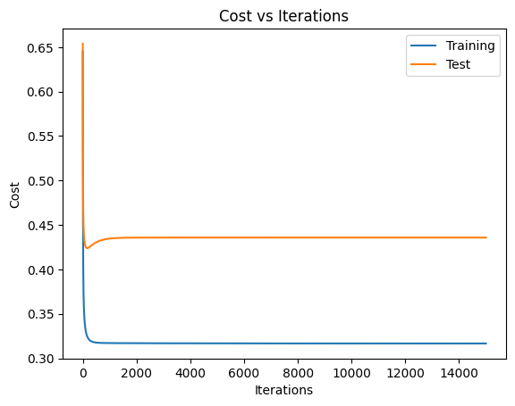

```python
import matplotlib.pyplot as plt

# plotting the learning curve as shown in the quizes
plt.plot(train_history, label='Training')
plt.plot(test_history, label='Test')
plt.xlabel('Iterations')
plt.ylabel('Cost')
plt.title('Cost vs Iterations')
plt.legend()
plt.show()
```

Task 2 has been completed using the given data. The data was loaded, shuffled, encoded, split, and scaled as required. The custom created model was then trained using generic hyperparameters that led to stable convergence as can be seen in the plotted learning curve. Thus all components of Task 2 have been completed successfully and shows that gradient descent is converging to a minimum, is stable, and that test cost is higher than training (almost to the point that suggest overfitting).

## 6 Task 3: Regularization Analysis - Finding the Optimal λ Value **(20 points)**

`lambda_reg` controls the strength of the regularization applied to the model.  
- When `lambda_reg` is set to **zero**, regularization is effectively turned off.  
- As `lambda_reg` increases, the penalty for large weights becomes more significant, helping to **reduce overfitting**.

### 6.1 🔧 Task Instructions

- Experiment with different values of `lambda_reg` in the set **[0.0, 0.01, 0.03, 0.1, 0.3]**.
- Plot the **learning curves** for both the training and test sets on the same figure to visualize the impact of each value.
- Determine which value of `lambda_reg` yields the **best performance** on this dataset.
- Report the performance (accuracy, precision, recall) using the best value of:
  - **Accuracy**
  - **Precision**
  - **Recall**

**Hyperparameters for this task**:  
- `learning_rate = 0.005`  
- `num_iterations = 1200`

```python
from sklearn.metrics import accuracy_score, precision_score, recall_score

# recreating w_in
w_in = np.zeros(X_train_scaled.shape[1])
# creating alpha and num_iters as given
alpha = 0.005
num_iters = 1200
# creating dictionary to store results accross the different lambdas
results = {}
# going through the given set of lambdas
for lambda_reg in [0.0, 0.01, 0.03, 0.1, 0.3]:
    # using the previously created and used function to find the results of gradient descent with different lambdas
    w, train_hist, test_hist = gradient_descent_logistic_ridge(X_train_scaled, y_train, X_test_scaled, y_test, w_in, alpha, num_iters, lambda_reg)
    # calculating accuracy, precision, and recall scores - start by calculating predicted values
    test_prob = 1 / (1 + np.exp(-np.column_stack([np.ones(X_test_scaled.shape[0]), X_test_scaled]) @ w)) # using sigmoid function to get f_w(x)
    y_pred_test = (test_prob >= 0.5).astype(int) # converting to category with default of o.5
    accuracy = accuracy_score(y_test, y_pred_test) # calculating accuracy, recall, and precision using sklearn
    precision = precision_score(y_test, y_pred_test)
    recall = recall_score(y_test, y_pred_test)
    # storing the results
    results[f"lambda_{lambda_reg}"] = {'w': w, 'train_hist': train_hist, 'test_hist': test_hist,
                                       'accuracy': accuracy, 'precision': precision, 'recall': recall}
```

[figure not shown]

```python
# creating a figure with multiple subplots to show all five learning curves as required
fig, axs = plt.subplots(2, 3, figsize = (12,8))
axs = axs.flatten()
# iterating through the results to plot everyting
for i, key in enumerate(results.keys()):
    ax = axs[i] # selecting a different subplot
    # plotting the
    ax.plot(results[key][1], label='Training')
    ax.plot(results[key][2], label='Test')
    ax.set_xlabel('Iterations')
    ax.set_ylabel('Cost')
    ax.set_title(key)
    ax.legend()

# hiding empty plot
axs[5].set_visible(False)
# showing the plot
plt.tight_layout()
plt.show()
```

```python
# getting lambda values to make column and initializing storage of all the other columns
lambda_values = list(results.keys())
final_test_cost = []
final_train_cost = []
accuracy = []
precision = []
recall = []
# iterating through the results dictionary to add to the df lists
for key in lambda_values:
    final_test_cost.append(results[key]['test_hist'][-1])
    final_train_cost.append(results[key]['train_hist'][-1])
    accuracy.append(results[key]['accuracy'])
    precision.append(results[key]['precision'])
    recall.append(results[key]['recall'])
# creating results df, sorting by final test cost to match instructions
results_df = pd.DataFrame({'lambda': lambda_values, 'final_train_cost': final_train_cost, 'final_test_cost': final_test_cost, 'accuracy': accuracy, 'precision': precision, 'recall': recall})
results_df.sort_values('final_test_cost', inplace=True)
results_df
```

|  | lambda | final_train_cost | final_test_cost | accuracy | precision | recall |
| --- | --- | --- | --- | --- | --- | --- |
| 0 | lambda_0.0 | 0.345721 | 0.432224 | 0.803279 | 0.810811 | 0.857143 |
| 1 | lambda_0.01 | 0.345753 | 0.432328 | 0.803279 | 0.810811 | 0.857143 |
| 2 | lambda_0.03 | 0.345819 | 0.432537 | 0.803279 | 0.810811 | 0.857143 |
| 3 | lambda_0.1 | 0.346049 | 0.433267 | 0.803279 | 0.810811 | 0.857143 |
| 4 | lambda_0.3 | 0.346704 | 0.435343 | 0.803279 | 0.810811 | 0.857143 |

From the graph and plotted learning curves above we can see that performance is very similar across all lambda values. The best single lambda value appears to be 0.0 as the final test cost is the lowest (though very close to all other final test costs). The performance metrics on the test set are all the same with accuracy of 0.803279, precision of 0.810811, and recall of 0.857143. This appears to indicate that the model does not have an overfitting issue as regularization does not have a noticeable effect on test set performance.

## 7 Task 4: Custom vs. scikit-learn — Comprehensive Benchmark Analysis **(20 points)**

- Use the **`LogisticRegression`** model from **scikit-learn** to re-evaluate the dataset while keeping the same (or as similar as possible) hyperparameter settings for a **fair comparison**.
- Report the performance using the **same evaluation metrics** as previously used.
- Compare the results to your **custom implementation**. Analyze whether scikit-learn’s built-in logistic regression achieves similar, better, or worse performance.
- Explain the potential reasons for any differences you observe.

```python
from sklearn.linear_model import LogisticRegression

# creating dictionary to store results accross the different lambdas - same as above
sklearn_results = {}
# calculating for lambda 0 or no penalty term
model = LogisticRegression(penalty = None, tol = 0.0, max_iter = 1200)
model.fit(X_train_scaled, y_train)
y_pred = model.predict(X_test_scaled)
# calculating accuracy, recall, and precision using sklearn - same evaluation metrics as previously used
accuracy = accuracy_score(y_test, y_pred)
precision = precision_score(y_test, y_pred)
recall = recall_score(y_test, y_pred)
# going through the given set of lambdas (minus zero as its done above - no penalty)
for lambda_reg in [0.01, 0.03, 0.1, 0.3]:
    # converting lambda values used to c
    c = 1 / lambda_reg
    # setting up logistic regression with all of the same parameters except alpha as LogisticRegression() does not use gradient descent but stochastic average gradient SGDClassifier would be need to influence larning rate
    model = LogisticRegression(penalty = 'l2', tol = 0.0, max_iter = 1200, C = c)
    model.fit(X_train_scaled, y_train)
    y_pred = model.predict(X_test_scaled)
    # calculating accuracy, recall, and precision using sklearn - same evaluation metrics as previously used
    accuracy = accuracy_score(y_test, y_pred)
    precision = precision_score(y_test, y_pred)
    recall = recall_score(y_test, y_pred)
    sklearn_results[f'lambda_{lambda_reg}'] = {'accuracy': accuracy, 'precision': precision, 'recall': recall}

sklearn_results[f'lambda_0.0'] = {'accuracy': accuracy, 'precision': precision, 'recall': recall}
```

```python
lambda_values = list(sklearn_results.keys())
accuracy = []
precision = []
recall = []
for key in lambda_values:
    accuracy.append(sklearn_results[key]['accuracy'])
    precision.append(sklearn_results[key]['precision'])
    recall.append(sklearn_results[key]['recall'])

sklearn_results_df = pd.DataFrame({'sklearn_lambda': ['sklearn_' + key for key in lambda_values], 'lambda': lambda_values, 'sklearn_accuracy': accuracy, 'sklearn_precision': precision, 'sklearn_recall': recall})
sklearn_results_df.sort_values('sklearn_accuracy', ascending = False, inplace=True)
sklearn_results_df
```

|  | sklearn_lambda | lambda | sklearn_accuracy | sklearn_precision | sklearn_recall |
| --- | --- | --- | --- | --- | --- |
| 0 | sklearn_lambda_0.01 | lambda_0.01 | 0.786885 | 0.775000 | 0.885714 |
| 1 | sklearn_lambda_0.03 | lambda_0.03 | 0.786885 | 0.775000 | 0.885714 |
| 2 | sklearn_lambda_0.1 | lambda_0.1 | 0.786885 | 0.775000 | 0.885714 |
| 3 | sklearn_lambda_0.3 | lambda_0.3 | 0.770492 | 0.769231 | 0.857143 |
| 4 | sklearn_lambda_0.0 | lambda_0.0 | 0.770492 | 0.769231 | 0.857143 |

Above the metrics used in Task 3 can be seen to analyze the performance of sklearn Logistic Regression. We can see that performance is almost idenitical across all lambda values matching what was seen in task 3 suggesting that the model itself does not suffer from overfitting issues as the training set is representative and large enough to match the variables used to predict it.

```python
display(results_df.head(1))
display(sklearn_results_df.head(1))
```

|  | lambda | final_train_cost | final_test_cost | accuracy | precision | recall |
| --- | --- | --- | --- | --- | --- | --- |
| 0 | lambda_0.0 | 0.345721 | 0.432224 | 0.803279 | 0.810811 | 0.857143 |

|  | sklearn_lambda | lambda | sklearn_accuracy | sklearn_precision | sklearn_recall |
| --- | --- | --- | --- | --- | --- |
| 0 | sklearn_lambda_0.01 | lambda_0.01 | 0.786885 | 0.775 | 0.885714 |

The comparison above shows that the sklearn model performance is comprabable to the custom model but has slightly worse accuracy and precision but slightly better recall. These differences are likely to emerge from sklearn not using gradient descent but the custom model uses gradient descent.

## 8 Task 5: Understanding Convergence - The `tol` Parameter Deep Dive **(15 points)**

In many models that use gradient descent–based optimization, `tol` is a key hyperparameter.  
In this task, you will explore its role using **logistic regression**.

### 8.1 **Understanding the Tolerance Parameter**

The `tol` parameter in sklearn’s LogisticRegression controls **when to stop the optimization process**:

- **What it measures**: Maximum change in the optimization objective between iterations
- **Stopping criterion**: Training stops when improvement falls below this threshold
- **Trade-off**: Tighter tolerance (smaller values) → more iterations → potentially better convergence
- **Efficiency**: Looser tolerance (larger values) → fewer iterations → faster training but potentially suboptimal results

### 8.2 **Mathematical Context**

For solver convergence, sklearn typically uses:
$$|\nabla J(\mathbf{w}^{(t)}) - \nabla J(\mathbf{w}^{(t-1)})| < \text{tol}$$
Or for objective function change:
$$|J(\mathbf{w}^{(t)}) - J(\mathbf{w}^{(t-1)})| < \text{tol}$$

### 8.3 **Expected Insights**

Experiment with the following `tol` values to explore their impact on model convergence, training speed, and performance:

**Typical Patterns You Should Observe:** - **Tighter tolerance (`1e-6`, `1e-7`)** → Training is slower but may yield slightly better performance.  
- **Moderate tolerance (`1e-4`, `1e-5`)** → A good balance between speed and accuracy (close to scikit-learn’s default).  
- **Loose tolerance (`1e-1`, `1e-2`)** → Faster training but may stop too early, leading to suboptimal results.  
- **Performance plateau** → Beyond a certain level of tightness, further decreasing tolerance does not yield meaningful gains.  
- **Convergence issues** → Extremely tight tolerance may require more iterations than allowed, preventing proper convergence.

### 8.4 ✅ **Success Criteria**

- Systematic testing across tolerance range (8+ values)
- Comprehensive performance and efficiency metrics
- Professional visualization with multiple perspectives
- Clear identification of trade-offs and recommendations
- Evidence-based analysis of sklearn’s default choice

```python
import time
# initializing list of 8 tolerances and dictionary to store results
tol_values = [1e-1, 1e-2, 1e-3, 1e-4, 1e-5, 1e-6, 1e-7, 1e-8]
tol_results = {'tol':[], 'accuracy': [], 'precision': [], 'recall': [], 'n_iter': [], 'training_time': []}
# iterating through all of the tol values and getting metrics
for tol in tol_values:
    # setting penalty to ridge, using current tol, and allowing for tolerance to be reached - all other parameters kept as default to show effect of tol
    model = LogisticRegression(penalty='l2', tol = tol, max_iter = 15000)
    start_time = time.time() # timing how long fitting takes
    model.fit(X_train_scaled, y_train) # fitting model
    training_time = time.time() - start_time # calculating time
    # getting number of iterations from the model
    n_iter = model.n_iter_[0]
    # getting predicition to get evaluation metrics
    y_pred = model.predict(X_test_scaled)
    accuracy = accuracy_score(y_test, y_pred)
    precision = precision_score(y_test, y_pred)
    recall = recall_score(y_test, y_pred)
    # storing results
    tol_results['tol'].append(tol)
    tol_results['accuracy'].append(accuracy)
    tol_results['precision'].append(precision)
    tol_results['recall'].append(recall)
    tol_results['n_iter'].append(n_iter)
    tol_results['training_time'].append(training_time)

tol_results_df = pd.DataFrame(tol_results)
tol_results_df
```

|  | tol | accuracy | precision | recall | n_iter | training_time |
| --- | --- | --- | --- | --- | --- | --- |
| 0 | 1.000000e-01 | 0.819672 | 0.833333 | 0.857143 | 1 | 0.001748 |
| 1 | 1.000000e-02 | 0.770492 | 0.769231 | 0.857143 | 4 | 0.003006 |
| 2 | 1.000000e-03 | 0.770492 | 0.769231 | 0.857143 | 8 | 0.003758 |
| 3 | 1.000000e-04 | 0.770492 | 0.769231 | 0.857143 | 17 | 0.005822 |
| 4 | 1.000000e-05 | 0.770492 | 0.769231 | 0.857143 | 18 | 0.005383 |
| 5 | 1.000000e-06 | 0.770492 | 0.769231 | 0.857143 | 22 | 0.005785 |
| 6 | 1.000000e-07 | 0.770492 | 0.769231 | 0.857143 | 24 | 0.006591 |
| 7 | 1.000000e-08 | 0.770492 | 0.769231 | 0.857143 | 27 | 0.006879 |

Above performance and efficiency metrics for 8 toleracnes are seen showing how the metrics change as tolerance increases.

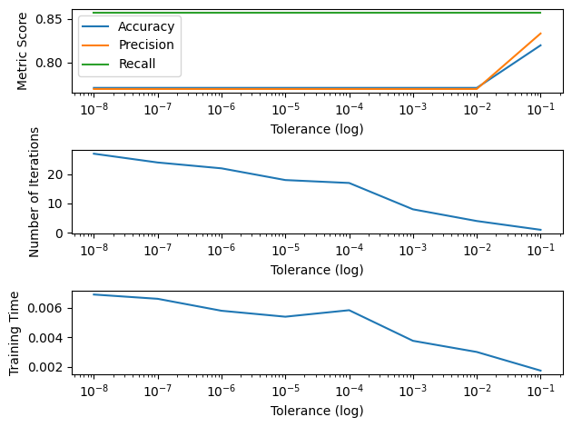

```python
# creating figure to show multiple viualizations of tolerance trade-offs
fig, axs = plt.subplots(3,1)

# plot one - model performance evaluation metrics vs tol
ax = axs[0]
ax.semilogx(tol_results_df['tol'], tol_results_df['accuracy'], label = 'Accuracy')
ax.semilogx(tol_results_df['tol'], tol_results_df['precision'], label = 'Precision')
ax.semilogx(tol_results_df['tol'], tol_results_df['recall'], label = 'Recall')
ax.set_xlabel('Tolerance (log)')
ax.set_ylabel('Metric Score')
ax.legend()

# plot 2 - iterations vs tol
ax = axs[1]
ax.semilogx(tol_results_df['tol'], tol_results_df['n_iter'])
ax.set_xlabel('Tolerance (log)')
ax.set_ylabel('Number of Iterations')

# plot 3 - time vs tol
ax = axs[2]
ax.semilogx(tol_results_df['tol'], tol_results_df['training_time'])
ax.set_xlabel('Tolerance (log)')
ax.set_ylabel('Training Time')

plt.tight_layout()
plt.show()
```

## 9 Bonus Task: Implementing `tol` in Your L2 Gradient Descent (15 points)

*This is a bonus task, feel free to skip this task*

To make your **custom L2-regularized gradient descent** implementation comparable with scikit-learn’s `LogisticRegression`, you should add the `tol` parameter as a **stopping criterion**.

### 9.1 ✅ Instructions:

1. During each iteration of gradient descent, compute the **change in cost (loss)** between the current and previous step.
2. If the change is **smaller than `tol`**, stop the training loop early.
3. Use the same tolerance values (`tol`) as in scikit-learn for a fair comparison.
4. Report:
   - The number of iterations completed before convergence.
   - Final training and test performance metrics.

```python
# updating gradient descent function created in task 1 to take tol parameter
def gradient_descent_logistic_ridge_tol(X_train, y_train, X_test, y_test, w_in, alpha, num_iters, lambda_reg, tol):
    # initializing storage
    J_history = []
    test_J_history = []
    # altering the passed data sets to add empty term
    train_x = np.column_stack([np.ones(X_train.shape[0]), X_train])
    test_x = np.column_stack([np.ones(X_test.shape[0]), X_test])
    # adding a bias to the passed w_in if it doesn't already exist
    if len(w_in) < train_x.shape[1]:
        w = np.zeros(len(w_in)+1)
        w[1:] = w_in
    else:
        w = np.copy(w_in)
    # running for passed number of iterations
    for i in range(num_iters):
        previous_cost = compute_cost_logistic_ridge(train_x, y_train, w, lambda_reg)
        # calculating the gradient using previoulsy made function - vectorized function
        dj_dw = compute_gradient_logistic_ridge(train_x, y_train, w, lambda_reg)
        # updating w
        w = w - (alpha * dj_dw)
        # calculating cost and adding to storage lists - vectorized function
        current_cost = compute_cost_logistic_ridge(train_x, y_train, w, lambda_reg)
        J_history.append(current_cost)
        test_J_history.append(compute_cost_logistic_ridge(test_x, y_test, w, lambda_reg))
        # checking to see if the improvement is less than the tolerance:
        if np.abs(previous_cost - current_cost) < tol: # if it is then calculate iterations and return all values
            iterations = i + 1
            return w, J_history, test_J_history, iterations

    # max iterations reached so returning that as the iteration number
    # returning final w, training and test history.
    return w, J_history, test_J_history, num_iters
```

```python
# recreating w_in
w_in = np.zeros(X_train_scaled.shape[1])
# matching parameters passed to sklearn - with alpha as before as no alpha passed to sklearn
alpha = 0.005
num_iters = 15000
lambda_reg = 1 # matching sklearn
tol_values = [1e-1, 1e-2, 1e-3, 1e-4, 1e-5, 1e-6, 1e-7, 1e-8]
# creating dictionary to store results accross the different tols
custom_tol_results = {'tol':[], 'test_accuracy': [], 'test_precision': [], 'test_recall': [], 'train_accuracy': [], 'train_precision': [], 'train_recall': [], 'n_iter': [], 'training_time': []}
# going through the given set of lambdas
for tol in tol_values:
    # using the previously created and used function to find the results of gradient descent with different lambdas
    start_time = time.time() # calculating time it takes
    w, train_hist, test_hist, n_iter = gradient_descent_logistic_ridge_tol(X_train_scaled, y_train, X_test_scaled, y_test, w_in, alpha, num_iters, lambda_reg, tol)
    training_time = time.time() - start_time
    # calculating accuracy, precision, and recall scores - start by calculating predicted values
    test_prob = 1 / (1 + np.exp(-np.column_stack([np.ones(X_test_scaled.shape[0]), X_test_scaled]) @ w)) # using sigmoid function to get f_w(x)
    y_pred_test = (test_prob >= 0.5).astype(int) # converting to category with default of o.5
    accuracy = accuracy_score(y_test, y_pred_test) # calculating accuracy, recall, and precision using sklearn
    precision = precision_score(y_test, y_pred_test)
    recall = recall_score(y_test, y_pred_test)
    # calculating accuracy, precision, and recall scores - start by calculating predicted values
    train_prob = 1 / (1 + np.exp(-np.column_stack([np.ones(X_train_scaled.shape[0]), X_train_scaled]) @ w)) # using sigmoid function to get f_w(x)
    y_pred_train = (train_prob >= 0.5).astype(int) # converting to category with default of o.5
    train_accuracy = accuracy_score(y_train, y_pred_train) # calculating accuracy, recall, and precision using sklearn
    train_precision = precision_score(y_train, y_pred_train)
    train_recall = recall_score(y_train, y_pred_train)
    # storing the results
    custom_tol_results['tol'].append(tol)
    custom_tol_results['test_accuracy'].append(accuracy)
    custom_tol_results['test_precision'].append(precision)
    custom_tol_results['test_recall'].append(recall)
    custom_tol_results['train_accuracy'].append(train_accuracy)
    custom_tol_results['train_precision'].append(train_precision)
    custom_tol_results['train_recall'].append(train_recall)
    custom_tol_results['n_iter'].append(n_iter)
    custom_tol_results['training_time'].append(training_time)

custom_tol_results_df = pd.DataFrame(custom_tol_results)
custom_tol_results_df
```

|  | tol | test_accuracy | test_precision | test_recall | train_accuracy | train_precision | train_recall | n_iter | training_time |
| --- | --- | --- | --- | --- | --- | --- | --- | --- | --- |
| 0 | 1.000000e-01 | 0.819672 | 0.833333 | 0.857143 | 0.842975 | 0.853846 | 0.853846 | 1 | 0.002685 |
| 1 | 1.000000e-02 | 0.819672 | 0.833333 | 0.857143 | 0.842975 | 0.853846 | 0.853846 | 1 | 0.002324 |
| 2 | 1.000000e-03 | 0.819672 | 0.833333 | 0.857143 | 0.847107 | 0.860465 | 0.853846 | 104 | 0.135092 |
| 3 | 1.000000e-04 | 0.803279 | 0.810811 | 0.857143 | 0.847107 | 0.854962 | 0.861538 | 544 | 0.700297 |
| 4 | 1.000000e-05 | 0.803279 | 0.810811 | 0.857143 | 0.863636 | 0.870229 | 0.876923 | 1903 | 2.602395 |
| 5 | 1.000000e-06 | 0.803279 | 0.794872 | 0.885714 | 0.867769 | 0.855072 | 0.907692 | 5205 | 6.797352 |
| 6 | 1.000000e-07 | 0.770492 | 0.769231 | 0.857143 | 0.863636 | 0.854015 | 0.900000 | 9940 | 11.882861 |
| 7 | 1.000000e-08 | 0.770492 | 0.769231 | 0.857143 | 0.863636 | 0.854015 | 0.900000 | 15000 | 19.605871 |

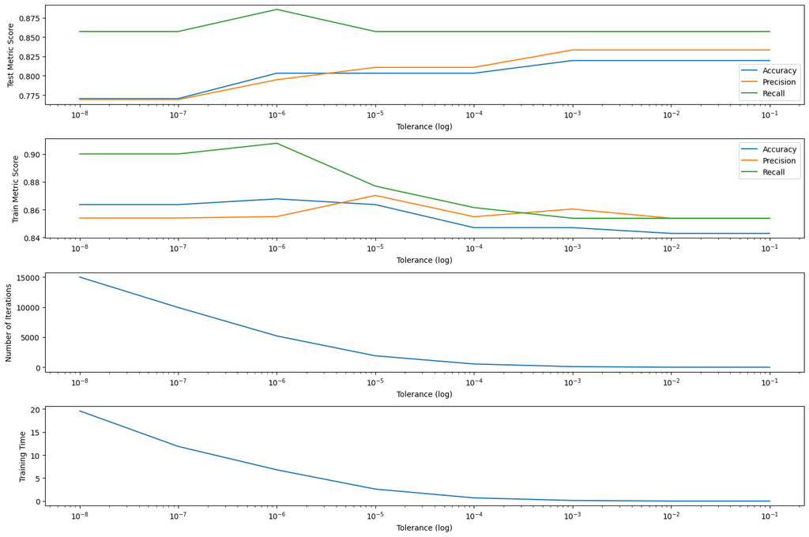

```python
# same figures as before
fig, axs = plt.subplots(4,1, figsize = (15,10))

# plot one - model performance evaluation metrics vs tol
ax = axs[0]
ax.semilogx(custom_tol_results_df['tol'], custom_tol_results_df['test_accuracy'], label = 'Accuracy')
ax.semilogx(custom_tol_results_df['tol'], custom_tol_results_df['test_precision'], label = 'Precision')
ax.semilogx(custom_tol_results_df['tol'], custom_tol_results_df['test_recall'], label = 'Recall')
ax.set_xlabel('Tolerance (log)')
ax.set_ylabel('Test Metric Score')
ax.legend()

# plot two - model performance evaluation metrics vs tol
ax = axs[1]
ax.semilogx(custom_tol_results_df['tol'], custom_tol_results_df['train_accuracy'], label = 'Accuracy')
ax.semilogx(custom_tol_results_df['tol'], custom_tol_results_df['train_precision'], label = 'Precision')
ax.semilogx(custom_tol_results_df['tol'], custom_tol_results_df['train_recall'], label = 'Recall')
ax.set_xlabel('Tolerance (log)')
ax.set_ylabel('Train Metric Score')
ax.legend()

# plot 3 - iterations vs tol
ax = axs[2]
ax.semilogx(custom_tol_results_df['tol'], custom_tol_results_df['n_iter'])
ax.set_xlabel('Tolerance (log)')
ax.set_ylabel('Number of Iterations')

# plot 4 - time vs tol
ax = axs[3]
ax.semilogx(custom_tol_results_df['tol'], custom_tol_results_df['training_time'])
ax.set_xlabel('Tolerance (log)')
ax.set_ylabel('Training Time')

plt.tight_layout()
plt.show()
```

We can see similar results between the custom function and the sklearn method, althought the custom function takes longer to run and requires more iterations. The test performance metrics follow a similar pattern althought it is more pronounce. The train performance metrics show the more expected result with lower tolerance leading to better performance.

## 10 Task 6: Summarize your findings below **(5 points)**

Cutom ridge logistic regression with vectorized gradient descent was created that was successfully used on the provided data set. Regularization did not appear to be necessary on the data as task 3 showed that the model performance seemed to be minorly affected by changing the lambda parameter. Comparison with sklearn LogisticRegression confirmed this result, and also showed that tolerance appeared to have an inverse effect suggest keeping initialized weights is the best for model performance. The custom ridge logistic regressor with tolerance also came to the same conclusion (althought it required more iterations). Outside of the technical development takeaways, the practical advice for using a model on this data is to check how the model performs before regularization and tolerance fitting as model performance may not always be improved through regularization and tolerance in a penalized regressor checks for a plateau as regularization is applied.

## 11 AI Use Disclosure **(5 pts)**

In **1–3 short paragraphs**, clearly state whether **generative AI tools** were used to complete any part of this assignment.

- If **no AI was used**, write:  
  *“I did not use generative AI tools on this assignment.”*
- If **AI was used**, you must specify:
  1. **Tool(s)** used (e.g., ChatGPT, GitHub Copilot, Claude, etc.)
  2. **How** they were used (e.g., idea generation, debugging, code suggestions, writing help)
  3. **Where** they influenced your work (which questions/sections)
  4. **Edits & verification** you made (how you checked correctness, what you modified)

### 11.1 AI Use Template

- **Used AI?** Yes / No
- **Tool(s):**
- **Purpose / How used (1–3 sentences):**
- **Scope (which questions/sections):**
- **Edits & verification (what you changed and how you checked correctness):**

> **Example (for illustration only):**  
> - Used AI? Yes  
> - Tools: ChatGPT (free), GitHub Copilot  
> - How used: Asked for a pandas snippet to impute missing values and for a seaborn example.  
> - Scope: Q1(b) imputation, Q2(a) first draft of bar chart code.  
> - Edits & verification: Rewrote code to use `groupby().transform('median')`; validated results by comparing summary stats; added axis labels manually.

**Grading (5 points):**  
- **5 points** = complete, specific, and honest (tools named, usage described clearly)  
- **3–4 points** = vague or missing some details  
- **1–2 points** = minimal effort or very unclear  
- **0 points** = missing or misleading disclosure

I used AI

Tool: Claude

How: asked to double check the math behind vectorization in the custom gradient descent, and to fix errors with plt plot

Scope: Task 1 checking math and efficient vectorization implementation, Task 3 error help with subplot indexing and plotting

Edits & verification: confirmed that my code in task 1 (suggested edits of grouping all the steps were not implemented) worked by running task 2 and the rest of the assignment without issue; confirmed subplots appeared as desired (included axs.flatten())